# Adult Steelhead Passage

Allison Bailey

2/18/2020

```r
# Attach packages

library(tidyverse)
library(janitor)
library(naniar)
library(VIM)
library(skimr)
library(ggfortify)
library(here)
library(lubridate)
library(anytime)
library(ggridges)
library(viridis)
library(hrbrthemes)
library(paletteer)
library(kableExtra)
library(ggpubr)
library(sf)
library(tmap)
library(DT)
library(plotly)
library(expss)
library(ggthemes)
library(knitr)
library(tsibble)
library(fable)
library(fabletools)
library(feasts)
library(forecast)
```

```r
# read in "bonneville_fish.csv" and clean data.

# drop the na's, parse the dates to have their own columns for ymd with lubridate. Use  mutate(date = paste(year, mm_dd, sep = "_")) to change format to date format.

bonn_fish <- read_csv("bonneville_fish.csv") %>%
  clean_names() %>%
  mutate(date = paste(year, mm_dd, sep = "_")) %>%
  mutate(date_parse = lubridate::ydm(date)) %>%
  mutate(month_sep = yearmonth(date_parse)) %>% #coerce to tsibble `yearmonth` format
  mutate(value = as.numeric(value)) %>%
  drop_na(month_sep, value) %>%
  mutate(month = month(date_parse)) %>%
  mutate(day = day(date_parse))
```

### Adult Steelhead passage through the Bonneville Dam

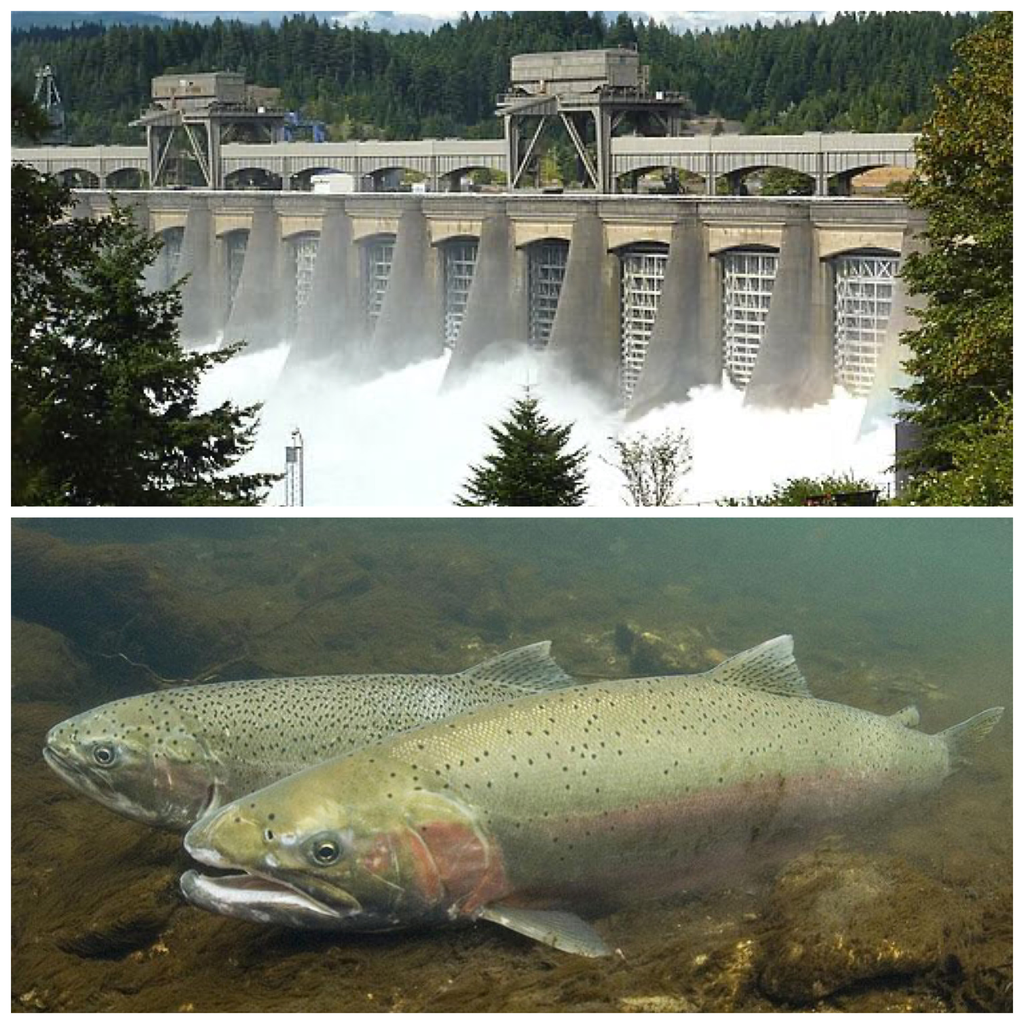

```r
#Insert snowshoe hare and map image with caption

include_graphics("image0.jpeg")
```

#### **Introduction**

Steelhead Trout, (*Oncorhynchus mykiss*), travel great distances to spawn in fresh-water rivers and streams. While some migrate back to the ocean, all Steelhead Trout hatch in fast flowing rivers and streams that are well-oxygenated[1]. These species are protected, as they have long been vulnerable dams blocking their spawning grounds as well as other anthropogenic degradation of aquatic habitats. In this report, we focus on adult Steelhead Trout pass through the Bonneville Dam which is located on the Columbia River east of Portland, OR. Bonneville Dam is a crucial power and water resource management system that is critical in managing fish and wildlife habitat[2].

Data from the Columbia River DART, Columbia Basin Research, University of Washington was utilized in this report to analyze time series trends in Adult Steelhead passage through the Bonneville Dam[3].

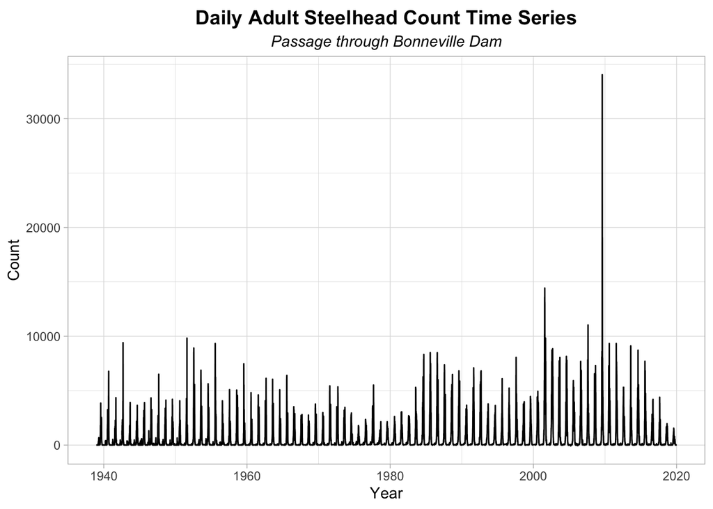

```r
# A finalized time series plot of the original observations (daily data).

fish_time <- ggplot(bonn_fish, aes(x = date_parse, y = value)) +
  geom_line() +
 theme_light() +
  theme(
    legend.position="none",
    plot.title = element_text(size=14)
  ) +
  theme(
    plot.title=element_text(hjust=0.5, vjust=0.5, face='bold'),
    plot.subtitle = element_text(hjust=0.5, vjust=0.5, face='italic')
  ) +
  labs(x = "Year",
       y = "Count",
       title = "Daily Adult Steelhead Count Time Series",
       subtitle = "Passage through Bonneville Dam")

fish_time
```

```r
# Create a tibble for monthly counts

fish_tibble <- bonn_fish %>%
  dplyr::select(month_sep, value) %>%
  group_by(month_sep) %>%
  summarise(
    month_total = sum(value)
  )

bonn_ts <- as_tsibble(fish_tibble, index = month_sep)
```

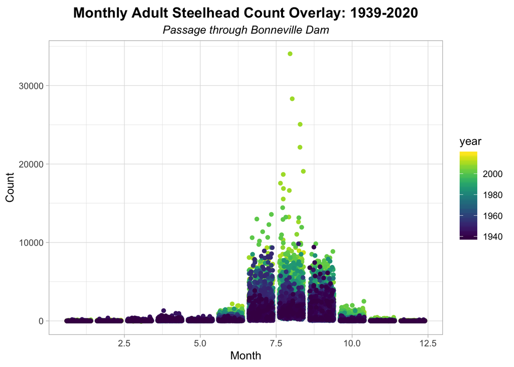

```r
# A finalized seasonplot to explore if/how monthly passage has shifted over time (I totaled counts by month before doing this...you can choose if you want to do that).  Steelhead can been seen throughout the year although most steelhead move past the lower Columbia River dams from July through September. There are two runs of steelhead: Summer: April through October. Winter: November through April.

bonn_monthly <- ggplot(data = bonn_fish, aes(x = month, y = value, group = year)) +
  geom_jitter(aes(color = year)) +
  scale_color_viridis() +
  theme_light() +
  theme(
    legend.position="right",
    plot.title = element_text(size=14)
  ) +
  theme(
    plot.title=element_text(hjust=0.5, vjust=0.5, face='bold'),
    plot.subtitle = element_text(hjust=0.5, vjust=0.5, face='italic')
  ) +
  labs(x = "Month",
       y = "Count",
       title = "Monthly Adult Steelhead Count Overlay: 1939-2020",
       subtitle = "Passage through Bonneville Dam")

bonn_monthly
```

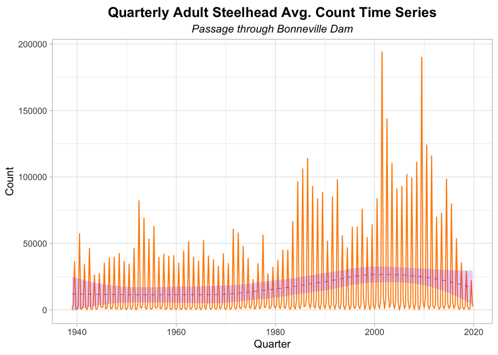

```r
# Now that we did a monthly, let's do a quarterly/seasonal graph

bonn_quarterly <- bonn_ts %>%
  index_by(year_qu = ~ yearquarter(.)) %>% # monthly aggregates
  summarise(
    avg_count = mean(month_total)
  )

bonn_seasonal <- ggplot(data = bonn_quarterly, aes(x = year_qu, y = avg_count)) +
  geom_line(color = "darkorange") +
  geom_smooth(color = "purple",
              size = 0.2,
              linetype = "dashed",
              fill = "purple",
              alpha = 0.2) +
  theme_minimal() +
   theme_light() +
  theme(
    legend.position="none",
    plot.title = element_text(size=14)
  ) +
  theme(
    plot.title=element_text(hjust=0.5, vjust=0.5, face='bold'),
    plot.subtitle = element_text(hjust=0.5, vjust=0.5, face='italic')
  ) +
  labs(x = "Quarter",
       y = "Count",
       title = "Quarterly Adult Steelhead Avg. Count Time Series",
       subtitle = "Passage through Bonneville Dam")

bonn_seasonal
```

For further analysis, take a look at the scroll table below to hone in on specific quarterly counts of adult Steelhead Trout passages through the Bonneville Dam from 1940-2020.

```r
kable(bonn_quarterly, col.names = c("Year/Quarter","Count"),
      caption = "***Figure 5.** The table below displays quarterly counts of steelhead fish passing through Bonneville Dam in the Columbia River.*") %>%
  kable_styling(bootstrap_options = "striped", position = "center") %>%
  add_header_above(c("Adult Steelhead Passage Count" = 2)) %>%
  scroll_box(width = "500px", height = "200px")
```

| Adult Steelhead Passage Count Year/Quarter | Adult Steelhead Passage Count Count |
| --- | --- |
| 1939 Q1 | 204.0000 |
| 1939 Q2 | 3729.0000 |
| 1939 Q3 | 36178.0000 |
| 1939 Q4 | 533.0000 |
| 1940 Q1 | 596.3333 |
| 1940 Q2 | 3204.0000 |
| 1940 Q3 | 57207.6667 |
| 1940 Q4 | 712.3333 |
| 1941 Q1 | 584.6667 |
| 1941 Q2 | 2968.0000 |
| 1941 Q3 | 34027.3333 |
| 1941 Q4 | 1782.3333 |
| 1942 Q1 | 99.0000 |
| 1942 Q2 | 3146.3333 |
| 1942 Q3 | 46166.6667 |
| 1942 Q4 | 1053.0000 |
| 1943 Q1 | 228.6667 |
| 1943 Q2 | 3212.0000 |
| 1943 Q3 | 26240.0000 |
| 1943 Q4 | 1036.3333 |
| 1944 Q1 | 409.3333 |
| 1944 Q2 | 3179.3333 |
| 1944 Q3 | 27411.0000 |
| 1944 Q4 | 2491.3333 |
| 1945 Q1 | 1696.3333 |
| 1945 Q2 | 2450.3333 |
| 1945 Q3 | 35092.3333 |
| 1945 Q4 | 789.6667 |
| 1946 Q1 | 1218.0000 |
| 1946 Q2 | 6195.3333 |

[output cut: 294 more lines]

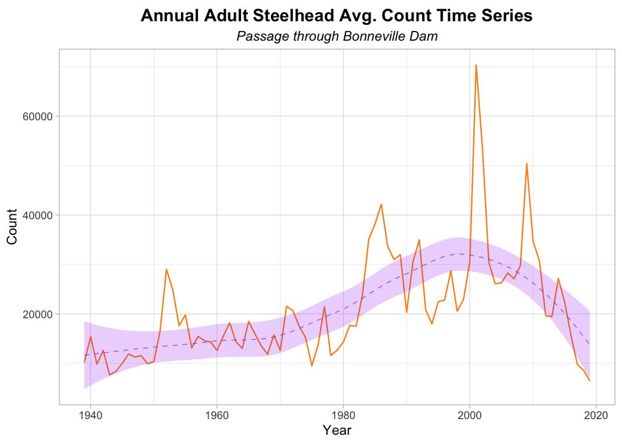

```r
# A finalized visualization of annual steelhead passage counts


bonn_annual <-bonn_ts %>%
  index_by(annual = ~year(.)) %>%
  summarize(
    avg_count = mean(month_total)
  )

bonn_annual_plot <- ggplot(data = bonn_annual, aes(x = annual, y = avg_count)) +
  geom_line(color = "darkorange") +
  geom_smooth(color = "purple",
              size = 0.2,
              linetype = "dashed",
              fill = "purple",
              alpha = 0.2) +
   theme_light() +
  theme(
    legend.position="none",
    plot.title = element_text(size=14)
  ) +
  theme(
    plot.title=element_text(hjust=0.5, vjust=0.5, face='bold'),
    plot.subtitle = element_text(hjust=0.5, vjust=0.5, face='italic')
  ) +
  labs(x = "Year",
       y = "Count",
       title = "Annual Adult Steelhead Avg. Count Time Series",
       subtitle = "Passage through Bonneville Dam")

bonn_annual_plot
```

#### **References**

[1] “Steelhead Trout - Oncorhynchus mykiss | NOAA Fisheries.” [Online]. Available: https://www.fisheries.noaa.gov/species/steelhead-trout

[2] “Bonneville Dam | US. Army Corp of Engineers.” [Online]. Available: https://www.nwp.usace.army.mil/bonneville/

[3] Columbia River DART, Columbia Basin Research, University of Washington. (2019). Adult Passage Graphics & Text. Available from http://www.cbr.washington.edu/dart/query/adult_graph_text

[4] “Managing the Columbia River to Help Fish | Bonneville Power Administration”. [Online]. Available at: https://www.bpa.gov/news/pubs/GeneralPublications/fish-Managing%20the%20Columbia%20River%20system%20to%20help%20fish.pdf